# Analyzing the R ToothGrowth Dataset

Karen S.

06/06/2020

## 1.1 Overview

This is a document for the second part of the Final Project of the Coursera Statistical Infernece Course by John Hopkins University. This report aims to analyze the ToothGrowth data from the R datasets package. As per the course project’s instructions, the following will be carried out:

```
- Load the ToothGrowth data and perform some basic exploratory data analyses
- Provide a basic summary of the data.
- Use confidence intervals and/or hypothesis tests to compare tooth growth by supp and dose.
- State your conclusions and the assumptions needed for your conclusions.
```

## 1.2 Loading the Data

The tooth growth data set is the length of the odontoblasts (teeth) in each of 10 guinea pigs at three Vitamin C dosage levels (0.5, 1, and 2 mg) with two delivery methods (orange juice or ascorbic acid).

The file contains 60 observations of 3 variables

```
- len : Tooth length
- supp : Supplement type (VC or OJ)
- dose : Dose in milligrams
```

```r
# Loading the Toothgrowth
data("ToothGrowth")
```

## 1.3 Data Summary

```r
# Displaying a summary of the data
summary(ToothGrowth)
```

```
##       len        supp         dose
##  Min.   : 4.20   OJ:30   Min.   :0.500
##  1st Qu.:13.07   VC:30   1st Qu.:0.500
##  Median :19.25           Median :1.000
##  Mean   :18.81           Mean   :1.167
##  3rd Qu.:25.27           3rd Qu.:2.000
##  Max.   :33.90           Max.   :2.000
```

```r
# Displaying the first few rows of data
head(ToothGrowth)
```

```
##    len supp dose
## 1  4.2   VC  0.5
## 2 11.5   VC  0.5
## 3  7.3   VC  0.5
## 4  5.8   VC  0.5
## 5  6.4   VC  0.5
## 6 10.0   VC  0.5
```

```r
# Displaying the unique values of the lengths the guinea pigs' tooth grew
unique(ToothGrowth$len)
```

```
##  [1]  4.2 11.5  7.3  5.8  6.4 10.0 11.2  5.2  7.0 16.5 15.2 17.3 22.5 13.6 14.5
## [16] 18.8 15.5 23.6 18.5 33.9 25.5 26.4 32.5 26.7 21.5 23.3 29.5 17.6  9.7  8.2
## [31]  9.4 19.7 20.0 25.2 25.8 21.2 27.3 22.4 24.5 24.8 30.9 29.4 23.0
```

```r
# Displaying the unique names of supplement delivery method
unique(ToothGrowth$supp)
```

```
## [1] VC OJ
## Levels: OJ VC
```

```r
# Displaying the unique dosage of supplements
unique(ToothGrowth$dose)
```

```
## [1] 0.5 1.0 2.0
```

## 1.4 Exploratory Data Analysis

Creating plots to explore the data further.

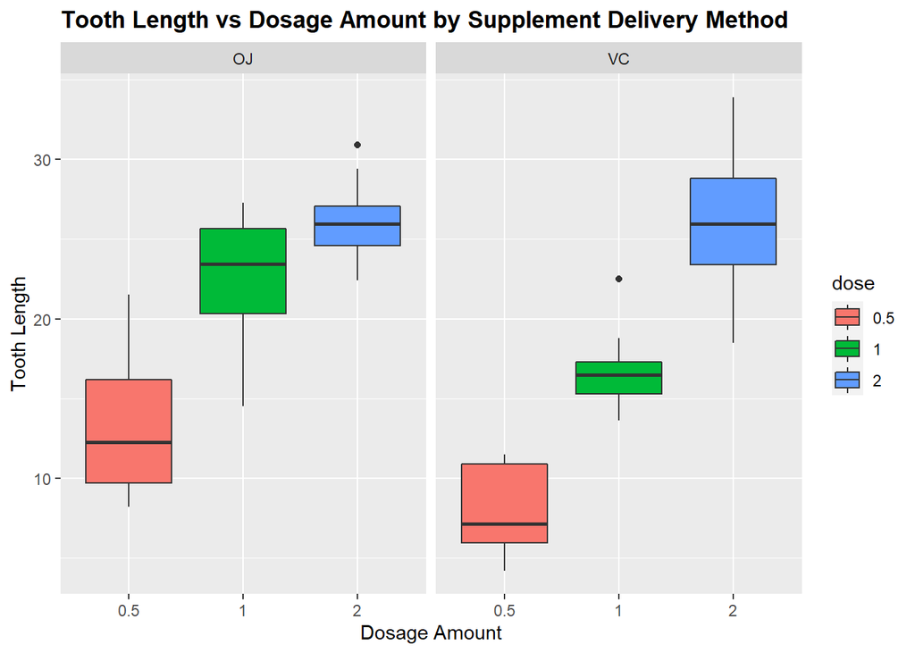

```r
library(ggplot2)

# Converting dose to a factor
ToothGrowth$dose <- as.factor(ToothGrowth$dose)

# Plotting the length ('len') vs the dosage ('dose'), grouped by supplement delivery method ('supp')
ggplot(aes(x=dose, y=len), data = ToothGrowth) +
    geom_boxplot(aes(fill=dose)) +
    xlab("Dosage Amount") +
    ylab("Tooth Length") +
    facet_grid(~ supp) +
    ggtitle("Tooth Length vs Dosage Amount by Supplement Delivery Method") +
    theme(plot.title = element_text(lineheight = .8, face = "bold"))
```

A similar pattern is observed within both supplement delivery methods whereby as the dosage increases the total length also increases.

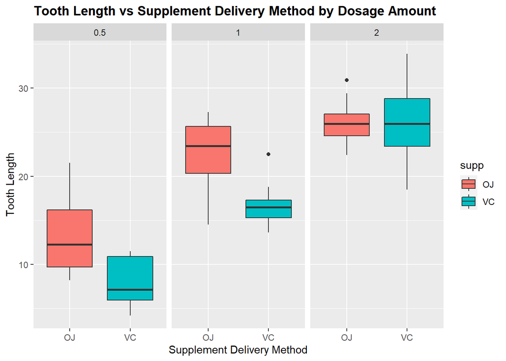

```r
# Plotting the length ('len') vs the supplement delivery method ('supp'), grouped by the dosage ('dose')
ggplot(aes(x=supp, y=len), data = ToothGrowth) +
    geom_boxplot(aes(fill=supp)) +
    xlab("Supplement Delivery Method") +
    ylab("Tooth Length") +
    facet_grid(~ dose) +
    ggtitle("Tooth Length vs Supplement Delivery Method by Dosage Amount") +
    theme(plot.title = element_text(lineheight = .8, face = "bold"))
```

It is observed that for lower dosages (0.5 and 1), the OJ delivery leads to more tooth growth than VC delviery. Both look to be equally effective when the dosage is 2.0.

Confidence intervals will be used to investigate the above statements.

For all confidence intervals, a 95% confidence is used.

## 1.5 Comparing Tooth Growth by Supplement Delivery Method and Dosage

## Hypothesis #1

The supplement delivery method results in the same tooth growth across the dataset (across all dosages).

```r
t.test(len~supp, paired=FALSE, var.equal=FALSE, data = ToothGrowth)
```

```
##
##  Welch Two Sample t-test
##
## data:  len by supp
## t = 1.9153, df = 55.309, p-value = 0.06063
## alternative hypothesis: true difference in means is not equal to 0
## 95 percent confidence interval:
##  -0.1710156  7.5710156
## sample estimates:
## mean in group OJ mean in group VC
##         20.66333         16.96333
```

It appears there is no difference between the two delivery methods when all of the data is lumped together. The confidence interval of the difference in means includes 0 and the p-value of the test is 0.06. Since it is greater than the 0.05 threshold, it is very close to being significant. The null hypothesis cannot be rejected.

## Hypothesis #2

For the dosage 0.5 mg, the two supplement delivery methods result in similar tooth growth.

```r
t.test(len~supp, paired=FALSE, var.equal=FALSE, data = subset(ToothGrowth, ToothGrowth$dose == 0.5))
```

```
##
##  Welch Two Sample t-test
##
## data:  len by supp
## t = 3.1697, df = 14.969, p-value = 0.006359
## alternative hypothesis: true difference in means is not equal to 0
## 95 percent confidence interval:
##  1.719057 8.780943
## sample estimates:
## mean in group OJ mean in group VC
##            13.23             7.98
```

The confidence interval does not include 0 and the p-value is below the 0.05 threshold. The null hypothesis can be rejected. The alternative hypothesis that the 0.5 mg dosage results in increased tooth growth is accepted - there is a significant difference between the mean growth between the two supplement delivery methods.

## Hypothesis #3

For the dosage 1.0 mg, the two supplement delivery methods result in similar tooth growth.

```r
t.test(len~supp, paired=FALSE, var.equal=FALSE, data = subset(ToothGrowth, ToothGrowth$dose == 1))
```

```
##
##  Welch Two Sample t-test
##
## data:  len by supp
## t = 4.0328, df = 15.358, p-value = 0.001038
## alternative hypothesis: true difference in means is not equal to 0
## 95 percent confidence interval:
##  2.802148 9.057852
## sample estimates:
## mean in group OJ mean in group VC
##            22.70            16.77
```

The confidence interval does not include 0 and the p-value is below the 0.05 threshold. The null hypothesis can be rejected. The alternative hypothesis that the 1.0 mg dosage results in increased tooth growth is accepted.

## Hypothesis #4

For the dosage 2.0 mg, the two supplement delivery methods result in similar tooth growth.

```r
t.test(len~supp, paired=FALSE, var.equal=FALSE, data = subset(ToothGrowth, ToothGrowth$dose == 2))
```

```
##
##  Welch Two Sample t-test
##
## data:  len by supp
## t = -0.046136, df = 14.04, p-value = 0.9639
## alternative hypothesis: true difference in means is not equal to 0
## 95 percent confidence interval:
##  -3.79807  3.63807
## sample estimates:
## mean in group OJ mean in group VC
##            26.06            26.14
```

The confidence interval does include 0 and the p-value is above the 0.05 threshold. The null hypothesis cannot be rejected - there is no significant difference between the mean tooth growth between the two supplement delivery methods.

## Hypothesis #5

For the 0.5 mg dosage via supplement delivery method OJ, there is similar tooth growth as the 1.0 mg dosage with the same supplement delivery method.

```r
t.test(len~dose, paired=FALSE, var.equal=FALSE, data = subset(ToothGrowth, ToothGrowth$supp == "OJ" & ToothGrowth$dose %in% c(0.5, 1)))
```

```
##
##  Welch Two Sample t-test
##
## data:  len by dose
## t = -5.0486, df = 17.698, p-value = 8.785e-05
## alternative hypothesis: true difference in means is not equal to 0
## 95 percent confidence interval:
##  -13.415634  -5.524366
## sample estimates:
## mean in group 0.5   mean in group 1
##             13.23             22.70
```

The confidence interval does not include 0 and the p-value is below the 0.05 threshold. The null hypothesis can be rejected - there is a significant difference between a 0.5 mg and 1.0 mg dose via the OJ supplement delivery method.

## Hypothesis #6

For the 0.5 mg dosage via supplement delivery method OJ, there is similar tooth growth as the 2.0 mg dosage with the same supplement delivery method.

```r
t.test(len~dose, paired=FALSE, var.equal=FALSE, data = subset(ToothGrowth, ToothGrowth$supp == "OJ" & ToothGrowth$dose %in% c(0.5, 2)))
```

```
##
##  Welch Two Sample t-test
##
## data:  len by dose
## t = -7.817, df = 14.668, p-value = 1.324e-06
## alternative hypothesis: true difference in means is not equal to 0
## 95 percent confidence interval:
##  -16.335241  -9.324759
## sample estimates:
## mean in group 0.5   mean in group 2
##             13.23             26.06
```

The confidence interval does not include 0 and the p-value is below the 0.05 threshold. The null hypothesis can be rejected - there is a significant difference between a 0.5 mg and 2.0 mg dose via the OJ supplement delivery method.

## Hypothesis #7

For the 1.0 mg dosage via supplement delivery method OJ, there is similar tooth growth as the 2.0 mg dosage with the same supplement delivery method.

```r
t.test(len~dose, paired=FALSE, var.equal=FALSE, data = subset(ToothGrowth, ToothGrowth$supp == "OJ" & ToothGrowth$dose %in% c(1, 2)))
```

```
##
##  Welch Two Sample t-test
##
## data:  len by dose
## t = -2.2478, df = 15.842, p-value = 0.0392
## alternative hypothesis: true difference in means is not equal to 0
## 95 percent confidence interval:
##  -6.5314425 -0.1885575
## sample estimates:
## mean in group 1 mean in group 2
##           22.70           26.06
```

## Hypothesis #8

For the 0.5 mg dosage via supplement delivery method VC, there is similar tooth growth as the 1.0 mg dosage with the same supplement delivery method.

```r
t.test(len~dose, paired=FALSE, var.equal=FALSE, data = subset(ToothGrowth, ToothGrowth$supp == "VC" & ToothGrowth$dose %in% c(0.5, 1)))
```

```
##
##  Welch Two Sample t-test
##
## data:  len by dose
## t = -7.4634, df = 17.862, p-value = 6.811e-07
## alternative hypothesis: true difference in means is not equal to 0
## 95 percent confidence interval:
##  -11.265712  -6.314288
## sample estimates:
## mean in group 0.5   mean in group 1
##              7.98             16.77
```

The confidence interval does not include 0 and the p-value is below the 0.05 threshold. The null hypothesis can be rejected - there is a significant difference between a 0.5 mg and 1.0 mg dose via the VC supplement delivery method.

## Hypothesis #9

For the 0.5 mg dosage via supplement delivery method VC, there is similar tooth growth as the 2.0 mg dosage with the same supplement delivery method.

```r
t.test(len~dose, paired=FALSE, var.equal=FALSE, data = subset(ToothGrowth, ToothGrowth$supp == "VC" & ToothGrowth$dose %in% c(0.5, 2)))
```

```
##
##  Welch Two Sample t-test
##
## data:  len by dose
## t = -10.388, df = 14.327, p-value = 4.682e-08
## alternative hypothesis: true difference in means is not equal to 0
## 95 percent confidence interval:
##  -21.90151 -14.41849
## sample estimates:
## mean in group 0.5   mean in group 2
##              7.98             26.14
```

The confidence interval does not include 0 and the p-value is below the 0.05 threshold. The null hypothesis can be rejected - there is a significant difference between a 0.5 mg and 2.0 mg dose via the VC supplement delivery method.

## Hypothesis #10

For the 1.0 mg dosage via supplement delivery method VC, there is similar tooth growth as the 2.0 mg dosage with the same supplement delivery method.

```r
t.test(len~dose, paired=FALSE, var.equal=FALSE, data = subset(ToothGrowth, ToothGrowth$supp == "VC" & ToothGrowth$dose %in% c(1, 2)))
```

```
##
##  Welch Two Sample t-test
##
## data:  len by dose
## t = -5.4698, df = 13.6, p-value = 9.156e-05
## alternative hypothesis: true difference in means is not equal to 0
## 95 percent confidence interval:
##  -13.054267  -5.685733
## sample estimates:
## mean in group 1 mean in group 2
##           16.77           26.14
```

The confidence interval does not include 0 and the p-value is below the 0.05 threshold. The null hypothesis can be rejected - there is a significant difference between a 1.0 mg and 2.0 mg dose via the VC supplement delivery method.

## 1.7 Assumptions

- It is assumed the measurements are not paired.
- It is not assumed that the variances are equal.
- The populations are assumed to be independent and there was no crossover between the subjects and dosage.
- It is assumed that the guinea pigs were truly selected at random so no conflating factors influenced the results.

## 1.8 Conclusions

- As the dosage increases, the tooth length increases regardless of the supplement method, as seen in Hypotheses #5-#10.
- At the 0.5 mg and 1.0 mg dosagesm the OJ supplement method leads to more tooth growth than the VC method as seen in Hypotheses #2 and #3.
- At the 2.0 mg dosage, there is no significant difference between the supplement delivery methods.